# Assessment 1

Ruben Adad

November 15, 2014

# Loading and preprocessing the data

```r
setwd("~/Documents/CURSOS/Reproducible Research/RepData_PeerAssessment1")
activity <- read.csv("activity.csv", stringsAsFactors=F)
summary(activity)
```

```
##      steps            date              interval
##  Min.   :  0.00   Length:17568       Min.   :   0.0
##  1st Qu.:  0.00   Class :character   1st Qu.: 588.8
##  Median :  0.00   Mode  :character   Median :1177.5
##  Mean   : 37.38                      Mean   :1177.5
##  3rd Qu.: 12.00                      3rd Qu.:1766.2
##  Max.   :806.00                      Max.   :2355.0
##  NA's   :2304
```

```r
head(activity)
```

```
##   steps       date interval
## 1    NA 2012-10-01        0
## 2    NA 2012-10-01        5
## 3    NA 2012-10-01       10
## 4    NA 2012-10-01       15
## 5    NA 2012-10-01       20
## 6    NA 2012-10-01       25
```

# What is mean total number of steps taken per day?

The following histogram shows the distribution of the total number of steps taken each day. The distribution **includes missing values**.

```r
library(dplyr)
```

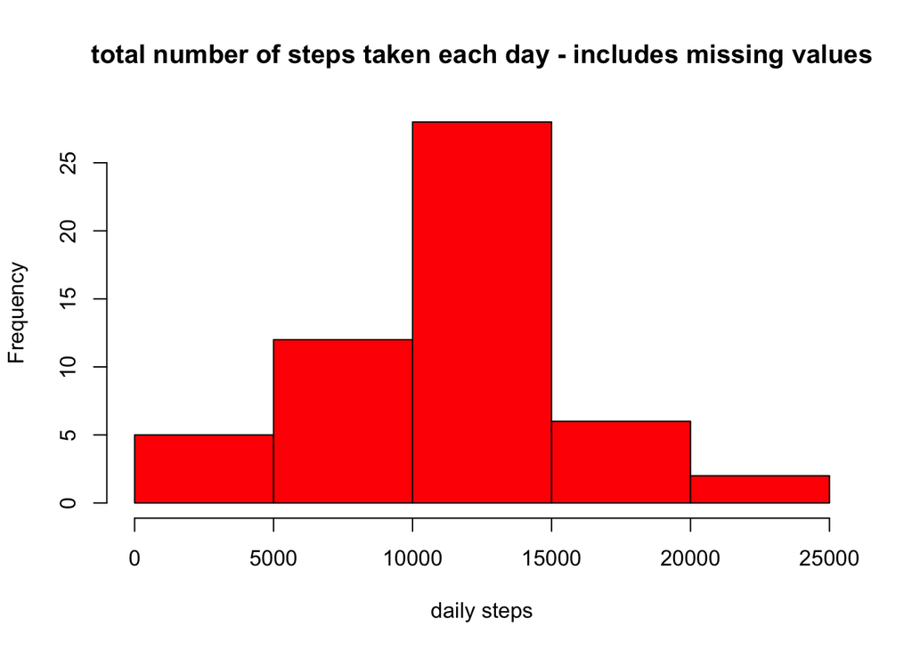

```r
grp <- group_by(activity, date)
tot_steps <- summarise(grp, Total_steps = sum(steps))
tot_steps$date <- as.Date(tot_steps$date, "%Y-%m-%d")
hist(tot_steps$Total_steps, main="total number of steps taken each day - includes missing values", xlab="daily steps", col="red")
```

```r
avg_steps <- summarise(grp, Mean = mean(steps), Median = median(steps))
```

### The mean and median total number of steps taken per day including missing values

```r
library(xtable)
print(xtable(as.data.frame(avg_steps), caption="mean and median steps taken per day"), html.table.attributes = list('border="2" bordercolor="blue" style=width:50%'), type="html")
```

mean and median steps taken per day

|  | date | Mean | Median |
| --- | --- | --- | --- |
| 1 | 2012-10-01 |  |  |
| 2 | 2012-10-02 | 0.44 | 0 |
| 3 | 2012-10-03 | 39.42 | 0 |
| 4 | 2012-10-04 | 42.07 | 0 |
| 5 | 2012-10-05 | 46.16 | 0 |
| 6 | 2012-10-06 | 53.54 | 0 |
| 7 | 2012-10-07 | 38.25 | 0 |
| 8 | 2012-10-08 |  |  |
| 9 | 2012-10-09 | 44.48 | 0 |
| 10 | 2012-10-10 | 34.38 | 0 |
| 11 | 2012-10-11 | 35.78 | 0 |
| 12 | 2012-10-12 | 60.35 | 0 |
| 13 | 2012-10-13 | 43.15 | 0 |
| 14 | 2012-10-14 | 52.42 | 0 |
| 15 | 2012-10-15 | 35.20 | 0 |
| 16 | 2012-10-16 | 52.38 | 0 |
| 17 | 2012-10-17 | 46.71 | 0 |
| 18 | 2012-10-18 | 34.92 | 0 |
| 19 | 2012-10-19 | 41.07 | 0 |
| 20 | 2012-10-20 | 36.09 | 0 |
| 21 | 2012-10-21 | 30.63 | 0 |
| 22 | 2012-10-22 | 46.74 | 0 |
| 23 | 2012-10-23 | 30.97 | 0 |
| 24 | 2012-10-24 | 29.01 | 0 |
| 25 | 2012-10-25 | 8.65 | 0 |
| 26 | 2012-10-26 | 23.53 | 0 |
| 27 | 2012-10-27 | 35.14 | 0 |
| 28 | 2012-10-28 | 39.78 | 0 |
| 29 | 2012-10-29 | 17.42 | 0 |
| 30 | 2012-10-30 | 34.09 | 0 |
| 31 | 2012-10-31 | 53.52 | 0 |
| 32 | 2012-11-01 |  |  |
| 33 | 2012-11-02 | 36.81 | 0 |
| 34 | 2012-11-03 | 36.70 | 0 |
| 35 | 2012-11-04 |  |  |
| 36 | 2012-11-05 | 36.25 | 0 |
| 37 | 2012-11-06 | 28.94 | 0 |
| 38 | 2012-11-07 | 44.73 | 0 |
| 39 | 2012-11-08 | 11.18 | 0 |
| 40 | 2012-11-09 |  |  |
| 41 | 2012-11-10 |  |  |
| 42 | 2012-11-11 | 43.78 | 0 |
| 43 | 2012-11-12 | 37.38 | 0 |
| 44 | 2012-11-13 | 25.47 | 0 |
| 45 | 2012-11-14 |  |  |
| 46 | 2012-11-15 | 0.14 | 0 |
| 47 | 2012-11-16 | 18.89 | 0 |
| 48 | 2012-11-17 | 49.79 | 0 |
| 49 | 2012-11-18 | 52.47 | 0 |
| 50 | 2012-11-19 | 30.70 | 0 |
| 51 | 2012-11-20 | 15.53 | 0 |
| 52 | 2012-11-21 | 44.40 | 0 |
| 53 | 2012-11-22 | 70.93 | 0 |
| 54 | 2012-11-23 | 73.59 | 0 |
| 55 | 2012-11-24 | 50.27 | 0 |
| 56 | 2012-11-25 | 41.09 | 0 |
| 57 | 2012-11-26 | 38.76 | 0 |
| 58 | 2012-11-27 | 47.38 | 0 |
| 59 | 2012-11-28 | 35.36 | 0 |
| 60 | 2012-11-29 | 24.47 | 0 |
| 61 | 2012-11-30 |  |  |

# What is the average daily activity pattern?

The following line chart shows the average number of steps taken per 5 minute interval. It also **includes missing values**.

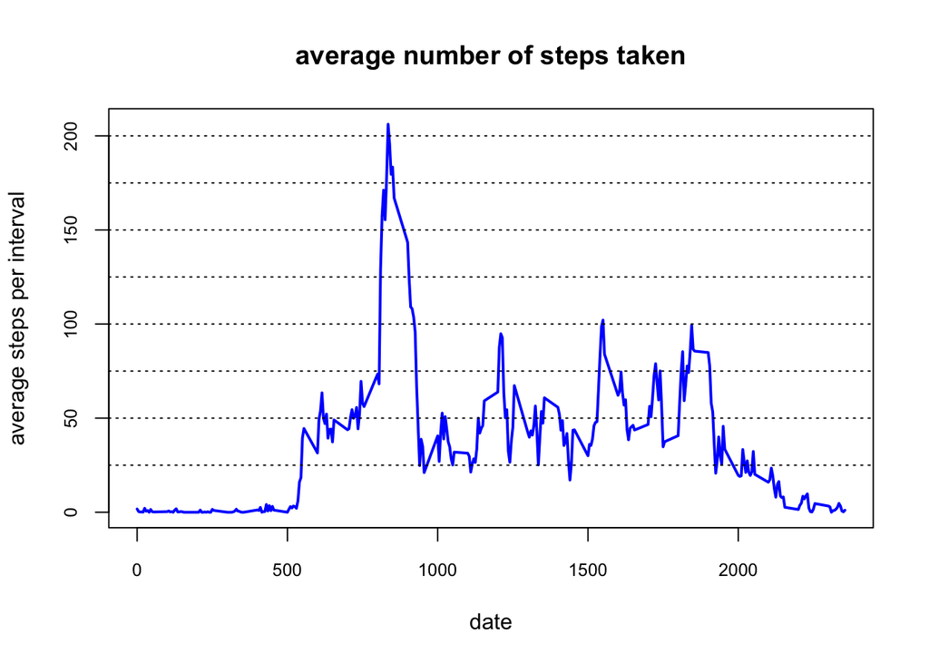

```r
grp <- group_by(activity, interval)
avg_interval <- summarise(grp, Mean = mean(steps, na.rm=T), Median = median(steps, na.rm=T))
plot(avg_interval$interval, avg_interval$Mean, type="l", lwd=2, col="blue", main="average number of steps taken", xlab="date", ylab="average steps per interval", cex.axis=0.8)
abline(h=c(25,50,75,100,125,150,175,200), lty=3)
```

```r
max_interval <- subset(avg_interval, avg_interval$Mean == max(na.omit(avg_interval$Mean)), select=c(interval, Mean))
```

The 5-minute interval with the maximum number of steps is: **835** with mean **206.1698113**.

# Imputing missing values

First I check for missing values in all the rows of the *activity* dataset.

```r
cc <- table(complete.cases(activity))
missing_values <- cc["FALSE"]
```

The total number of rows with missing values is: 2304  
Then I calculate the mean of all the non-missing values of the *steps* variable. And assign it to all the missing values of de *Mean* attribute in the *avg_steps* data frame.  
Next I paste the *avg_steps* data frame to the *activity* data frame using a left join by *date*.  
Finally, I assign the *Mean* variable from *avg_steps* to the missing values of the *steps* variable in the *activity* data frame and drop the *Mean* and *Median* columns.

```r
avg_steps$Mean[which(complete.cases(avg_steps) %in% "FALSE")] <- mean(na.omit(activity$steps))
new_activity <- left_join(activity, avg_steps)
new_activity$steps[which(complete.cases(new_activity$steps) %in% "FALSE")] <- new_activity$Mean[which(complete.cases(new_activity$steps) %in% "FALSE")]
new_activity <- subset(new_activity, select=c("date", "steps", "interval"))
```

Now I repeat the sum of *steps* group by date to create the histogram **without missing values**. And then to print the mean and median of the number of steps per day.  
**As can be seen this result is different from the previous one which includes missing values.**

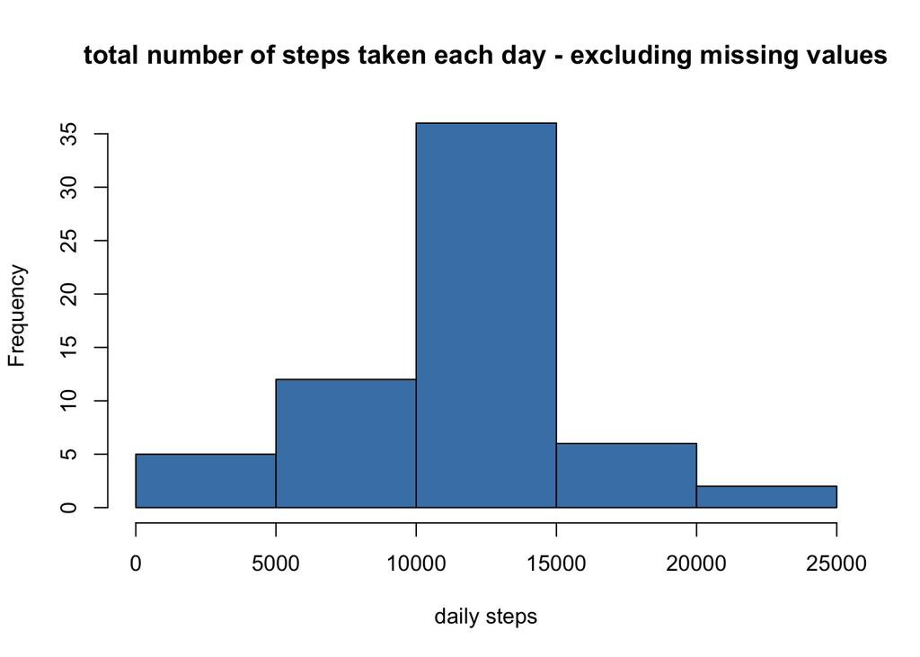

```r
grp <- group_by(new_activity, date)
tot_steps <- summarise(grp, Total_steps = sum(steps))
tot_steps$date <- as.Date(tot_steps$date, "%Y-%m-%d")
hist(tot_steps$Total_steps, main="total number of steps taken each day - excluding missing values", xlab="daily steps", col="steelblue")
```

```r
avg_steps <- summarise(grp, Mean = mean(steps), Median = median(steps))
```

### The mean and median total number of steps taken per day excluding missing values

```r
print(xtable(as.data.frame(avg_steps), caption="mean and median steps taken per day"), html.table.attributes = list('border="2" bordercolor="blue" style=width:50%'), type="html")
```

mean and median steps taken per day

|  | date | Mean | Median |
| --- | --- | --- | --- |
| 1 | 2012-10-01 | 37.38 | 37.38 |
| 2 | 2012-10-02 | 0.44 | 0.00 |
| 3 | 2012-10-03 | 39.42 | 0.00 |
| 4 | 2012-10-04 | 42.07 | 0.00 |
| 5 | 2012-10-05 | 46.16 | 0.00 |
| 6 | 2012-10-06 | 53.54 | 0.00 |
| 7 | 2012-10-07 | 38.25 | 0.00 |
| 8 | 2012-10-08 | 37.38 | 37.38 |
| 9 | 2012-10-09 | 44.48 | 0.00 |
| 10 | 2012-10-10 | 34.38 | 0.00 |
| 11 | 2012-10-11 | 35.78 | 0.00 |
| 12 | 2012-10-12 | 60.35 | 0.00 |
| 13 | 2012-10-13 | 43.15 | 0.00 |
| 14 | 2012-10-14 | 52.42 | 0.00 |
| 15 | 2012-10-15 | 35.20 | 0.00 |
| 16 | 2012-10-16 | 52.38 | 0.00 |
| 17 | 2012-10-17 | 46.71 | 0.00 |
| 18 | 2012-10-18 | 34.92 | 0.00 |
| 19 | 2012-10-19 | 41.07 | 0.00 |
| 20 | 2012-10-20 | 36.09 | 0.00 |
| 21 | 2012-10-21 | 30.63 | 0.00 |
| 22 | 2012-10-22 | 46.74 | 0.00 |
| 23 | 2012-10-23 | 30.97 | 0.00 |
| 24 | 2012-10-24 | 29.01 | 0.00 |
| 25 | 2012-10-25 | 8.65 | 0.00 |
| 26 | 2012-10-26 | 23.53 | 0.00 |
| 27 | 2012-10-27 | 35.14 | 0.00 |
| 28 | 2012-10-28 | 39.78 | 0.00 |
| 29 | 2012-10-29 | 17.42 | 0.00 |
| 30 | 2012-10-30 | 34.09 | 0.00 |
| 31 | 2012-10-31 | 53.52 | 0.00 |
| 32 | 2012-11-01 | 37.38 | 37.38 |
| 33 | 2012-11-02 | 36.81 | 0.00 |
| 34 | 2012-11-03 | 36.70 | 0.00 |
| 35 | 2012-11-04 | 37.38 | 37.38 |
| 36 | 2012-11-05 | 36.25 | 0.00 |
| 37 | 2012-11-06 | 28.94 | 0.00 |
| 38 | 2012-11-07 | 44.73 | 0.00 |
| 39 | 2012-11-08 | 11.18 | 0.00 |
| 40 | 2012-11-09 | 37.38 | 37.38 |
| 41 | 2012-11-10 | 37.38 | 37.38 |
| 42 | 2012-11-11 | 43.78 | 0.00 |
| 43 | 2012-11-12 | 37.38 | 0.00 |
| 44 | 2012-11-13 | 25.47 | 0.00 |
| 45 | 2012-11-14 | 37.38 | 37.38 |
| 46 | 2012-11-15 | 0.14 | 0.00 |
| 47 | 2012-11-16 | 18.89 | 0.00 |
| 48 | 2012-11-17 | 49.79 | 0.00 |
| 49 | 2012-11-18 | 52.47 | 0.00 |
| 50 | 2012-11-19 | 30.70 | 0.00 |
| 51 | 2012-11-20 | 15.53 | 0.00 |
| 52 | 2012-11-21 | 44.40 | 0.00 |
| 53 | 2012-11-22 | 70.93 | 0.00 |
| 54 | 2012-11-23 | 73.59 | 0.00 |
| 55 | 2012-11-24 | 50.27 | 0.00 |
| 56 | 2012-11-25 | 41.09 | 0.00 |
| 57 | 2012-11-26 | 38.76 | 0.00 |
| 58 | 2012-11-27 | 47.38 | 0.00 |
| 59 | 2012-11-28 | 35.36 | 0.00 |
| 60 | 2012-11-29 | 24.47 | 0.00 |
| 61 | 2012-11-30 | 37.38 | 37.38 |

# Are there differences in activity patterns between weekdays and weekends?

I use the function “isWeekend” from the “timeDate” package to determine if a date is weekend or weekday. Then I replace the logical values TRUE/FALSE with weekend/weekday respectively.  
I generate the comparative graph using ggplot.  
**As can be seen from the red trendline, weekend and weekdays have different patterns.**

```r
library(timeDate)
```

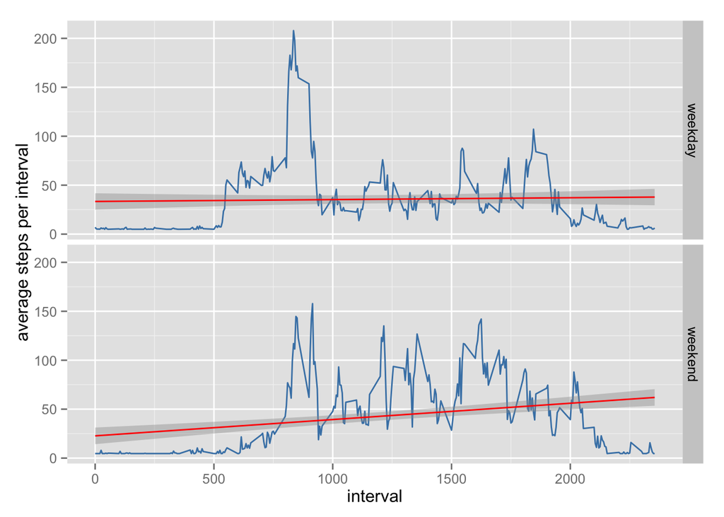

```r
library(ggplot2)
new_activity$weekend <- factor(isWeekend(as.Date(new_activity$date)))
new_activity$weekend <- gsub("TRUE", "weekend", new_activity$weekend)
new_activity$weekend <- gsub("FALSE", "weekday", new_activity$weekend)
grp <- group_by(new_activity, weekend, interval)
avg_interval <- summarise(grp, Mean = mean(steps), Median = median(steps))
g <- ggplot(avg_interval, aes(interval, Mean))
g + geom_line(color="steelblue") + facet_grid(weekend ~ .) + labs(y = "average steps per interval") + geom_smooth(method="lm", color="red")
```